# Definition relevanter Parameter

```python
# Filepath of dataset
filename = 'datasets/1run_225_end_compression_particle-data_joints.csv'

# Diameter and height of hypha element
d_hypha = 6.3    # [µm]
h_hypha = 1.575   # [µm]

# Cell wall thickness
d_wall = 0.1      # [µm]
```

# Einlesen und vorbereiten der Daten

Einlesen der CSV in Dataframe und Ausgabe einiger Zeilen

```python
import pandas as pd
import numpy as np
import matplotlib.pyplot as plt
import math

# Read the CSV into a pandas DataFrame
df = pd.read_csv(filename, skiprows=[1])  # Skip the second row with the time information

df.head(20)
```

|  | Tensile Stress | Particle ID From | Shear Stress | Coordinate : Y | von Mises Stress | Coordinate : X | Coordinate : Z | Particle ID To |
| --- | --- | --- | --- | --- | --- | --- | --- | --- |
| 0 | 15.47400 | 30574.0 | 28.7137 | -0.000166 | 54.8628 | -0.000241 | 0.000046 | 30575.0 |
| 1 | 14.40580 | 30575.0 | 26.7306 | -0.000167 | 51.1890 | -0.000242 | 0.000046 | 30576.0 |
| 2 | 17.19890 | 30573.0 | 30.5817 | -0.000165 | 58.7392 | -0.000240 | 0.000045 | 30574.0 |
| 3 | 9.96378 | 121074.0 | 14.2815 | -0.000161 | 29.4453 | -0.000241 | 0.000035 | 121075.0 |
| 4 | 12.97660 | 121073.0 | 15.1627 | -0.000161 | 33.2843 | -0.000241 | 0.000036 | 121074.0 |
| 5 | 15.54780 | 121072.0 | 17.2394 | -0.000161 | 38.5749 | -0.000240 | 0.000038 | 121073.0 |
| 6 | 16.42550 | 121071.0 | 18.2068 | -0.000161 | 40.3510 | -0.000239 | 0.000039 | 121072.0 |
| 7 | 15.32810 | 121070.0 | 18.7830 | -0.000161 | 40.5033 | -0.000239 | 0.000041 | 121071.0 |
| 8 | 12.90180 | 121069.0 | 19.0170 | -0.000162 | 39.3203 | -0.000239 | 0.000042 | 121070.0 |
| 9 | 9.39987 | 121068.0 | 20.6907 | -0.000162 | 39.9059 | -0.000238 | 0.000044 | 121069.0 |
| 10 | 18.66350 | 30572.0 | 32.5570 | -0.000164 | 63.0499 | -0.000239 | 0.000045 | 30573.0 |
| 11 | 15.14130 | 30571.0 | 25.8812 | -0.000162 | 50.0397 | -0.000238 | 0.000045 | 30572.0 |
| 12 | 11.29170 | 30572.0 | 16.1794 | -0.000162 | 33.1842 | -0.000238 | 0.000045 | 121068.0 |
| 13 | 3.29953 | 30571.0 | 22.5873 | -0.000162 | 40.0490 | -0.000238 | 0.000045 | 121068.0 |
| 14 | 14.30030 | 30570.0 | 52.0079 | -0.000161 | 93.0839 | -0.000237 | 0.000045 | 30571.0 |
| 15 | 20.37180 | 30569.0 | 53.6918 | -0.000161 | 98.7697 | -0.000235 | 0.000045 | 30570.0 |
| 16 | 25.18790 | 30568.0 | 55.4661 | -0.000160 | 103.8890 | -0.000234 | 0.000045 | 30569.0 |
| 17 | 0.00000 | 15090.0 | 1067.4300 | -0.000142 | 1848.8500 | -0.000196 | 0.000004 | 15091.0 |
| 18 | 0.00000 | 15089.0 | 1067.3700 | -0.000141 | 1848.7400 | -0.000196 | 0.000004 | 15090.0 |
| 19 | 0.00000 | 15088.0 | 1067.2000 | -0.000139 | 1848.4500 | -0.000195 | 0.000005 | 15089.0 |

Umbenennung der Spalten um die Datenauswertung zu erleichtern

```python
new_column_names = {
    'Tensile Stress': 'stress_tensile',
    'Particle ID From': 'id_from',
    'Shear Stress': 'stress_shear',
    'Coordinate : Y': 'pos_y',
    'von Mises Stress': 'stress_mises',
    'Coordinate : X': 'pos_x',
    'Coordinate : Z': 'pos_z',
    'Particle ID To': 'id_to',
}

df.rename(columns=new_column_names, inplace=True)

df.sample(5)
```

|  | stress_tensile | id_from | stress_shear | pos_y | stress_mises | pos_x | pos_z | id_to |
| --- | --- | --- | --- | --- | --- | --- | --- | --- |
| 101106 | 0.0000 | 6016.0 | 326.961 | 0.000039 | 566.314 | 0.000053 | 0.000003 | 6017.0 |
| 59576 | 2668.5300 | 22848.0 | 4837.650 | 0.000122 | 8793.800 | -0.000018 | 0.000132 | 22849.0 |
| 88675 | 87.1628 | 44978.0 | 403.107 | -0.000039 | 709.301 | 0.000030 | 0.000119 | 44979.0 |
| 82707 | 1.4540 | 68265.0 | 2205.580 | -0.000031 | 3820.220 | 0.000205 | 0.000048 | 68266.0 |
| 42451 | 0.0000 | 36465.0 | 5422.320 | 0.000059 | 9391.740 | -0.000045 | 0.000024 | 36466.0 |

Löschen der uninteressanten Spalten

```python
# columns_to_drop = ['id_from', 'id_to', 'stress_mises', 'stress_shear']
columns_to_drop = ['stress_mises', 'stress_shear']
df.drop(columns=columns_to_drop, inplace=True)

new_order = ['id_from', 'id_to', 'pos_x', 'pos_y', 'pos_z', 'stress_tensile']

# apply new order
df = df[new_order]
df.sample(5)
```

|  | id_from | id_to | pos_x | pos_y | pos_z | stress_tensile |
| --- | --- | --- | --- | --- | --- | --- |
| 112187 | 34175.0 | 34176.0 | 0.000089 | 0.000223 | 0.000039 | 4.5067 |
| 99578 | 42127.0 | 42128.0 | 0.000210 | -0.000071 | 0.000144 | 367.9620 |
| 2806 | 15823.0 | 15824.0 | -0.000234 | -0.000044 | 0.000053 | 102.0690 |
| 16951 | 41027.0 | 41028.0 | -0.000062 | -0.000060 | 0.000088 | 0.0000 |
| 17482 | 58065.0 | 58066.0 | -0.000070 | -0.000047 | 0.000064 | 0.0000 |

Umrechnen der Koordinaten von Meter in µm und Berechnung des 2D bzw. 3D Abstandes zum Schwerpunkt

```python
df['pos_x'] *= 1e6
df['pos_y'] *= 1e6
df['pos_z'] *= 1e6

x_mean = df['pos_x'].mean()
y_mean = df['pos_y'].mean()
z_mean = df['pos_z'].mean()

z_plate_min = df['pos_z'].min() - d_hypha/2
z_plate_max = df['pos_z'].max() + d_hypha/2

# find absolute maximum of x and y
xy_max = abs(df[['pos_x', 'pos_y']]).max().max()

# correction of stress as this only acts on the cell wall
A_hypha_full = (d_hypha/2)**2 * math.pi
A_hypha_ring = A_hypha_full - ((d_hypha-2*d_wall)/2)**2 * math.pi
stress_factor = A_hypha_full / A_hypha_ring
df['stress_tensile_wall'] = df['stress_tensile'] * stress_factor
df.drop(columns='stress_tensile', inplace=True)

# convert stress to kilopascal
df['stress_tensile_wall'] /= 1000

df['radius'] = ((df['pos_x']-x_mean)**2 + (df['pos_y']-x_mean)**2).apply(np.sqrt)
df['radius_3d'] = ((df['pos_x']-x_mean)**2 + (df['pos_y']-y_mean)**2 + (df['pos_z']-z_mean)**2).apply(np.sqrt)

df.sample(5)
```

|  | id_from | id_to | pos_x | pos_y | pos_z | stress_tensile_wall | radius | radius_3d |
| --- | --- | --- | --- | --- | --- | --- | --- | --- |
| 87546 | 69957.0 | 69958.0 | 46.3996 | -89.9357 | 117.533 | 0.000000 | 100.394429 | 117.703767 |
| 62108 | 108730.0 | 108731.0 | -79.4066 | 120.7260 | 169.443 | 0.000000 | 145.082974 | 154.228589 |
| 35565 | 101760.0 | 101761.0 | -30.6269 | -55.2695 | 149.567 | 0.197296 | 60.539850 | 95.678963 |
| 94012 | 70925.0 | 70926.0 | 40.0171 | -43.0245 | 166.695 | 0.000000 | 58.722695 | 104.373131 |
| 97785 | 65016.0 | 65017.0 | 204.9530 | -50.3286 | 120.337 | 0.999967 | 212.484925 | 218.736161 |

Übersicht bzw. Beschreibung der Werte des Dataframes

```python
df.describe()
```

|  | id_from | id_to | pos_x | pos_y | pos_z | stress_tensile_wall | radius | radius_3d |
| --- | --- | --- | --- | --- | --- | --- | --- | --- |
| count | 129837.000000 | 129837.000000 | 129837.000000 | 129837.000000 | 129837.000000 | 129837.000000 | 129837.000000 | 129837.000000 |
| mean | 60390.843265 | 63114.699100 | -1.951587 | 13.737188 | 89.815286 | 21.167441 | 147.091729 | 155.741460 |
| std | 35588.602840 | 36091.185781 | 118.888847 | 103.857563 | 48.565134 | 68.065773 | 59.421776 | 54.990312 |
| min | 1.000000 | 2.000000 | -310.038000 | -276.395000 | 3.144430 | 0.000000 | 0.504789 | 7.541114 |
| 25% | 29490.000000 | 31923.000000 | -95.825300 | -67.860600 | 48.552600 | 0.000000 | 104.257019 | 114.764272 |
| 50% | 59759.000000 | 63382.000000 | -1.619870 | 9.589480 | 89.692600 | 0.091750 | 149.729606 | 156.957527 |
| 75% | 90840.000000 | 94492.000000 | 91.813900 | 92.865500 | 130.369000 | 3.614287 | 191.151419 | 196.163496 |
| max | 124598.000000 | 124599.000000 | 315.437000 | 328.369000 | 177.016000 | 1136.281489 | 340.257117 | 333.717443 |

# Einlesen und Verarbeiten der Elementdaten

```python
# Read the CSV into a pandas DataFrame
filename_elements = 'datasets/1run_225_end_compression_particle-data_elements.csv'
df_elements = pd.read_csv(filename_elements, skiprows=[1])

#rename columns
new_column_names = {
    'Particle Y-Coordinate': 'pos_y',
    'Force : Tangential': 'force_tangential',
    'Orientation Vector Y': 'orientation_vec_y',
    'Particle Mass': 'mass',
    'Particle ID': 'id',
    'Orientation Angle': 'orientation_angle',
    'Force : Normal': 'force_normal',
    'Orientation Vector X': 'orientation_vec_x',
    'Orientation Vector Z': 'orientation_vec_z',
    'Particle Volume': 'volume',
    'Particle Z-Coordinate': 'pos_z',
    'Particle X-Coordinate': 'pos_x',
}
df_elements.rename(columns=new_column_names, inplace=True)

# delete unused columns
columns_to_drop = ['force_tangential', 'orientation_vec_x', 'orientation_vec_y', 'orientation_vec_z',
                   'mass', 'orientation_angle', 'force_normal', 'volume']
df_elements.drop(columns=columns_to_drop, inplace=True)

# reordner
new_order = ['id', 'pos_x', 'pos_y', 'pos_z']
df_elements = df_elements[new_order]

# convert m to µm
df_elements['pos_x'] *= 1e6
df_elements['pos_y'] *= 1e6
df_elements['pos_z'] *= 1e6

# convert column 'id' to integer and use it as index
df_elements['id'] = df_elements['id'].astype(int)
df_elements.set_index("id", inplace=True)

df_elements
```

| id | pos_x | pos_y | pos_z |
| --- | --- | --- | --- |
| 1 | -1.34784 | -10.8914 | 116.512 |
| 2 | -2.27895 | -11.0646 | 115.253 |
| 3 | -3.21009 | -11.2378 | 113.995 |
| 4 | -4.14126 | -11.4110 | 112.736 |
| 5 | -5.07240 | -11.5842 | 111.478 |
| ... | ... | ... | ... |
| 124595 | -241.83500 | -57.7191 | 68.855 |
| 124596 | 22.76200 | 133.7260 | 170.410 |
| 124597 | 23.74620 | 134.9020 | 170.763 |
| 124598 | 24.73020 | 136.0790 | 171.115 |
| 124599 | 25.71420 | 137.2560 | 171.466 |

124599 rows × 3 columns

# Ermittlung der Orientierung an jedem Gelenk

```python
# returns the coordinates of element with passed id as nd.array
def get_position(element_id):
    element = df_elements.loc[element_id]
    position_element = [element['pos_x'], element['pos_y'], element['pos_z']]
    return np.array(position_element)

# returns second legendre polynomial (of Z-Axis) for a row of a dataframe
def cal_P2(row):
    position_from = get_position(row['id_from'])
    position_to = get_position(row['id_to'])
    ori_vctr = position_to - position_from

    thetaZ = np.arccos(ori_vctr[2]/ np.linalg.norm(ori_vctr))
    P2 = 0.5 * (3 * np.cos(thetaZ) ** 2 - 1)
    return P2

# calculate second legendre polynomial for each joint
df['P2'] = df.apply(cal_P2, axis=1)
```

# Berechnung der [Summen-] Verteilung

```
     stress_tensile_wall  quantity  cumulative_sum
0               4.029367  102316.0        102316.0
1              12.088101    4919.0        107235.0
2              20.146835    3058.0        110293.0
3              28.205569    2136.0        112429.0
4              36.264303    1715.0        114144.0
..                   ...       ...             ...
136          1100.017186       2.0        129834.0
137          1108.075920       0.0        129834.0
138          1116.134654       0.0        129834.0
139          1124.193388       0.0        129834.0
140          1132.252122       2.0        129836.0

[141 rows x 3 columns]
```

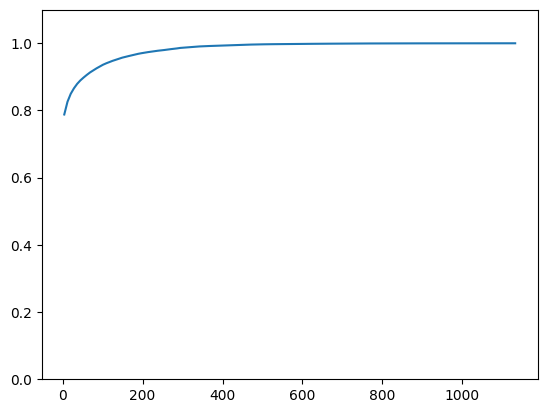

```python
# Define the bins for the distribution
bins_min = 0
bins_max = df['stress_tensile_wall'].max()
bins_step = bins_max / 141
bins = np.arange(bins_min, bins_max, bins_step)

# Create a new dataframe for distribution analysis
distribution_df = pd.DataFrame(columns=['stress_tensile_wall', 'quantity'])

# Populate the new dataframe with mean tensile stress and quantity information
for i in range(int(bins_max/bins_step)):
    lower_bound = i * bins_step
    upper_bound = lower_bound + bins_step
    subset = df[df['stress_tensile_wall'].between(lower_bound, upper_bound, inclusive='left')]
    distribution_df.loc[i] = [i*bins_step + bins_step / 2, subset.shape[0]]

distribution_df['cumulative_sum'] = distribution_df['quantity'].cumsum()
print(distribution_df)

distribution_df['cumulative_sum'] = distribution_df['cumulative_sum'] / distribution_df['cumulative_sum'].max()
plt.plot(distribution_df['stress_tensile_wall'], distribution_df['cumulative_sum'])
plt.ylim(0,1.1)

plt.show()
```

Plotten über integrierte Funktion

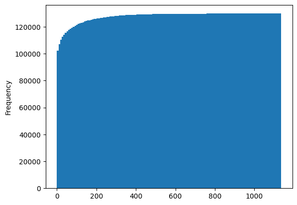

```python
ax = df['stress_tensile_wall'].plot.hist(bins=141, cumulative=True)
```

# Auswerten einer einzelnen Scheibe bei z_mean

Erstellen eines neuen Dataframes mit Werten von Gelenken in einzelner Scheibe in X-Y-Ebene

```python
z_layer_position = z_mean  # [µm] position of center of layer
z_layer_height = d_hypha     # [µm]

z_min = z_layer_position - z_layer_height/2
z_max = z_layer_position + z_layer_height/2
df_layer = df[(df['pos_z'] >= z_min) & (df['pos_z'] < z_max)]
df_layer.describe()
```

|  | id_from | id_to | pos_x | pos_y | pos_z | stress_tensile_wall | radius | radius_3d | P2 |
| --- | --- | --- | --- | --- | --- | --- | --- | --- | --- |
| count | 4912.000000 | 4912.000000 | 4912.000000 | 4912.000000 | 4912.000000 | 4912.000000 | 4912.000000 | 4912.000000 | 4912.000000 |
| mean | 54367.526466 | 56782.186889 | 2.143095 | 12.022172 | 89.794733 | 27.140873 | 148.821891 | 148.388782 | -0.090174 |
| std | 36951.561704 | 37753.311632 | 120.535267 | 105.316727 | 1.791792 | 90.046298 | 60.662789 | 60.162879 | 0.415055 |
| min | 23.000000 | 24.000000 | -269.591000 | -216.534000 | 86.666100 | 0.000000 | 3.469309 | 9.480221 | -0.500000 |
| 25% | 20038.750000 | 22467.750000 | -89.169275 | -72.449450 | 88.299800 | 0.000000 | 105.935407 | 106.349147 | -0.436083 |
| 50% | 51437.500000 | 55183.500000 | 6.317400 | 6.879040 | 89.727400 | 0.089703 | 151.072667 | 149.798465 | -0.247146 |
| 75% | 85706.250000 | 90468.000000 | 97.234000 | 101.018000 | 91.309050 | 3.451346 | 191.389909 | 188.736424 | 0.167742 |
| max | 124586.000000 | 124587.000000 | 293.196000 | 328.369000 | 92.963600 | 1030.141147 | 330.494887 | 314.814940 | 0.999901 |

Plotten der Spannungen innerhalb der Scheibe

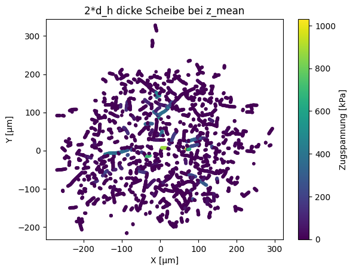

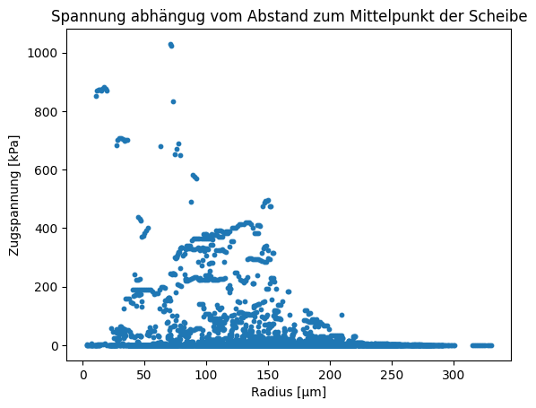

```python
plt.scatter(df_layer['pos_x'], df_layer['pos_y'], c=df_layer['stress_tensile_wall'], cmap='viridis', s=10)
plt.colorbar(label='Zugspannung [kPa]')  # Add color bar for reference

plt.xlabel('X [µm]')
plt.ylabel('Y [µm]')
plt.axis('equal')
plt.title('2*d_h dicke Scheibe bei z_mean')
plt.show()

plt.scatter(df_layer['radius'], df_layer['stress_tensile_wall'],s=10)
plt.xlabel('Radius [µm]')
plt.ylabel('Zugspannung [kPa]')
plt.title('Spannung abhängug vom Abstand zum Mittelpunkt der Scheibe')
plt.show()
```

# Auswertung sämtlicher Gelenke

Plotten der Spannungen abhängig vom Abstand zum Schwerpunkt (Gesamtes Pellet)

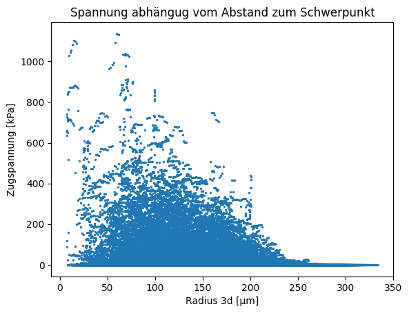

```python
plt.scatter(df['radius_3d'], df['stress_tensile_wall'],s=2)
plt.xlabel('Radius 3d [µm]')
plt.ylabel('Zugspannung [kPa]')
plt.title('Spannung abhängug vom Abstand zum Schwerpunkt')
plt.show()
```

Plotten der Spannungen abhängig vom Legendre-Polynom

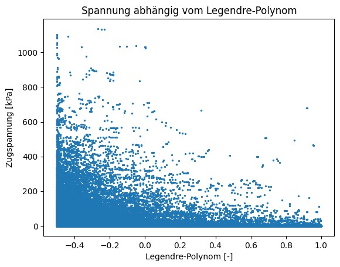

```python
plt.scatter(df['P2'], df['stress_tensile_wall'],s=2)
plt.xlabel('Legendre-Polynom [-]')
plt.ylabel('Zugspannung [kPa]')
plt.title('Spannung abhängig vom Legendre-Polynom')
plt.show()
```

Spannungen gemittelt auf kleine Abschnitte

```python
bins_min = -0.5
bins_max = 1
bins_step = 0.02

bins = np.arange(bins_min, bins_max + bins_step, bins_step)

# Create a new column 'P2_bin' with bin labels
df['P2_bin'] = pd.cut(df['P2'], bins=bins, right=False)

# Calculate mean stress_tensile for each P2_bin
mean_stress_by_bin = df.groupby('P2_bin', observed=True)['stress_tensile_wall'].mean().reset_index()
mean_stress_by_bin.rename(columns={'stress_tensile_wall' : 'stress_tensile_mean'}, inplace=True)
mean_stress_by_bin['midpoint'] = mean_stress_by_bin['P2_bin'].apply(lambda interval: (interval.left + interval.right) / 2)
mean_stress_by_bin
```

|  | P2_bin | stress_tensile_mean | midpoint |
| --- | --- | --- | --- |
| 0 | [-0.5, -0.48) | 35.290099 | -0.49 |
| 1 | [-0.48, -0.46) | 30.302065 | -0.47 |
| 2 | [-0.46, -0.44) | 32.161147 | -0.45 |
| 3 | [-0.44, -0.42) | 29.921979 | -0.43 |
| 4 | [-0.42, -0.4) | 30.522800 | -0.41 |
| ... | ... | ... | ... |
| 70 | [0.9, 0.92) | 2.457220 | 0.91 |
| 71 | [0.92, 0.94) | 2.446116 | 0.93 |
| 72 | [0.94, 0.96) | 3.545913 | 0.95 |
| 73 | [0.96, 0.98) | 1.097180 | 0.97 |
| 74 | [0.98, 1.0) | 1.397078 | 0.99 |

75 rows × 3 columns

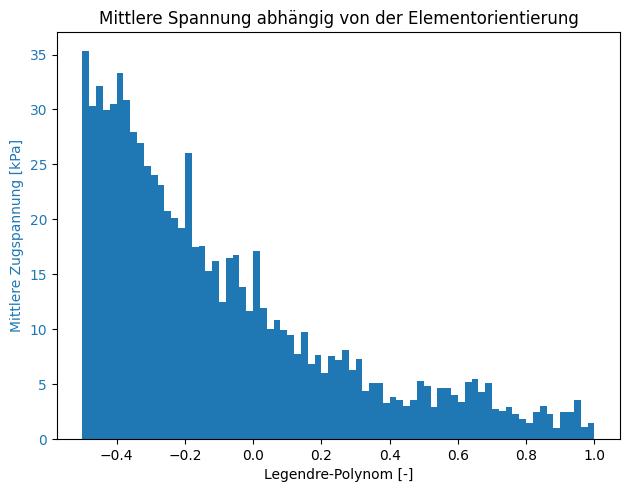

```python
bar_width = bins_step

fig, ax = plt.subplots()

# Plot mean stress_tensile
color = 'tab:blue'
ax.set_xlabel('Legendre-Polynom [-]')
ax.set_ylabel('Mittlere Zugspannung [kPa]', color=color)
ax.bar(mean_stress_by_bin['midpoint'], mean_stress_by_bin['stress_tensile_mean'], color=color, width=bar_width)
ax.tick_params(axis='y', labelcolor=color)
# ax.set_xlim(bins_min-bins_step, bins_max+bins_step)

fig.tight_layout()
plt.title('Mittlere Spannung abhängig von der Elementorientierung')
plt.show()
```

Plotten aller Gelenke, deren Spannung mindestens 30% der maximalen Spannung entspricht.

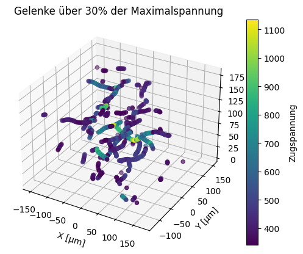

```python
# from mpl_toolkits.mplot3d import Axes3D  # Importing 3D axes for Matplotlib

df_high_stress = df[df['stress_tensile_wall'] >= df['stress_tensile_wall'].max() *  0.3]

# Create a 3D plot
fig = plt.figure()
ax = fig.add_subplot(111, projection='3d')

# Scatter plot with pos_x, pos_y, pos_z as coordinates and stress_tensile as color
scatter = ax.scatter(df_high_stress['pos_x'], df_high_stress['pos_y'], df_high_stress['pos_z'], c=df_high_stress['stress_tensile_wall'], cmap='viridis')

# Add labels
ax.set_xlabel('X [µm]')
ax.set_ylabel('Y [µm]')
ax.set_zlabel('Z [µm]')
ax.set_title('Gelenke über 30% der Maximalspannung')

# Add colorbar
cbar = fig.colorbar(scatter, ax=ax, label='Zugspannung')

# Show the plot
plt.show()
```

Berechnen der maximalen und mittleren Spannung abhängig von der X-Y-Position (gemittelt auf Raster mit 5µm-Schritten)

```python
from matplotlib.ticker import MaxNLocator

grid_spacing = 5

# round grid_max to next int divisible by grid_spacing
grid_max = math.ceil(xy_max / grid_spacing) * grid_spacing
grid_min = - grid_max

grid_number = (grid_max - grid_min) / grid_spacing

x_y_axis = np.linspace(grid_min, grid_max - grid_spacing, int(grid_number))
x, y = np.meshgrid(x_y_axis, x_y_axis)

stress_mean = np.full_like(x, np.nan)
stress_max = np.full_like(x, np.nan)
stress_count = np.full_like(x, np.nan)

for i in range(len(x_y_axis) -1):
    for j in range(len(x_y_axis) -1):
        x_val = x[i, j]
        y_val = y[i, j]
        # stess cell = all stresses that are between x_j and x_j+1 and between y_i and y_i+1
        stress_cell = df.loc[((df['pos_x'] >= x[i, j]) & (df['pos_x'] < x[i, j+1]))
                        & ((df['pos_y'] >= y[i, j]) & (df['pos_y'] < y[i+1, j])), 'stress_tensile_wall']
        # calulating mean and max stress for each cell of grid
        stress_mean[i, j] = stress_cell.mean()
        stress_max[i,j] = stress_cell.max()
        stress_count[i,j] = stress_cell.size

#correct x and y so it refers to the middle of the cell
x = x + grid_spacing/2
y = y + grid_spacing/2
```

Plotten der mittleren Spannungen in X-Y-Ebene

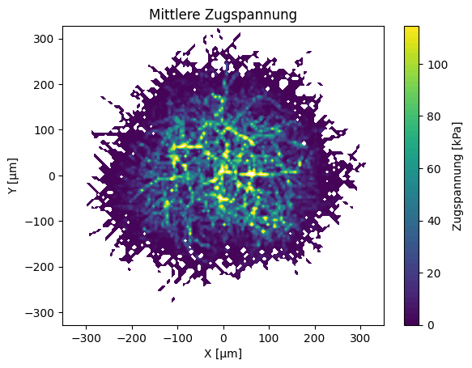

```python
cbar_max_stress = np.nanmax(stress_mean)*0.33
levels = np.linspace(0, cbar_max_stress, 55)
fig, ax = plt.subplots()
plt.title('Mittlere Zugspannung')
plt.axis('equal')
plt.xlabel('X [µm]')
plt.ylabel('Y [µm]')
contour = ax.contourf(x, y, stress_mean, levels=levels, cmap='viridis')
cbar = fig.colorbar(contour, ticks=MaxNLocator(nbins=6))
cbar.set_label('Zugspannung [kPa]')
```

Plotten der maximalen Spannungen in X-Y-Ebene

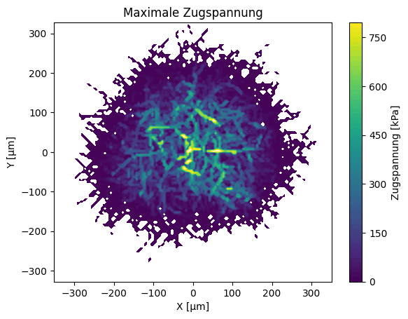

```python
cbar_max_stress = np.nanmax(stress_max)*0.7
levels = np.linspace(0, cbar_max_stress, 55)
fig, ax = plt.subplots()
plt.title('Maximale Zugspannung')
plt.axis('equal')
plt.xlabel('X [µm]')
plt.ylabel('Y [µm]')
contour = ax.contourf(x, y, stress_max, levels=levels, cmap='viridis')
cbar = fig.colorbar(contour, ticks=MaxNLocator(nbins=6))
cbar.set_label('Zugspannung [kPa]')
```

Plotten der Anzahl der Gelenke pro 5x5 µm Zelle

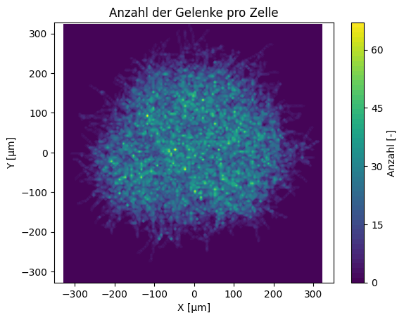

```python
cbar_max_stress = np.nanmax(stress_count)
levels = np.linspace(0, cbar_max_stress, 55)
fig, ax = plt.subplots()
plt.title('Anzahl der Gelenke pro Zelle')
plt.axis('equal')
plt.xlabel('X [µm]')
plt.ylabel('Y [µm]')
contour = ax.contourf(x, y, stress_count, levels=levels, cmap='viridis')
cbar = fig.colorbar(contour, ticks=MaxNLocator(nbins=6))
cbar.set_label('Anzahl [-]')
```

Und nochmal für die X-Z-Ebene

```python
grid_z_min = z_plate_min
grid_z_max = z_plate_max
grid_z_number = int((grid_z_max - grid_z_min) / grid_spacing)

x_y_axis = np.linspace(grid_min, grid_max - grid_spacing, int(grid_number))
z_axis = np.linspace(grid_z_min, grid_z_max - grid_spacing, int(grid_z_number))
x, z = np.meshgrid(x_y_axis, z_axis)

stress_mean = np.full_like(x, np.nan)
stress_max = np.full_like(x, np.nan)
stress_count = np.full_like(x, np.nan)


for i in range(len(z_axis) -1):
    for j in range(len(x_y_axis) -1):
        x_val = x[i, j]
        z_val = z[i, j]
        stress_cell = df.loc[((df['pos_x'] >= x[i, j]) & (df['pos_x'] < x[i, j+1]))
                        & ((df['pos_z'] >= z[i, j]) & (df['pos_z'] < z[i+1, j])), 'stress_tensile_wall']
        # calulating mean and max stress for each cell of grid
        stress_mean[i, j] = stress_cell.mean()
        stress_max[i,j] = stress_cell.max()
        stress_count[i,j] = stress_cell.size

#correct x and y so it refers to the middle of the cell
x = x + grid_spacing/2
z = z + grid_spacing/2
```

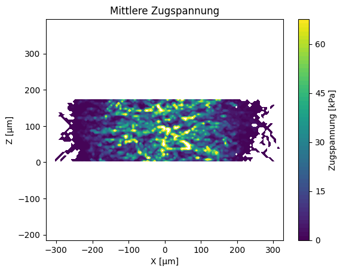

```python
cbar_max_stress = np.nanmax(stress_mean)*0.33
levels = np.linspace(0, cbar_max_stress, 55)
fig, ax = plt.subplots()
plt.title('Mittlere Zugspannung')
plt.axis('equal')
plt.xlabel('X [µm]')
plt.ylabel('Z [µm]')
contour = ax.contourf(x, z, stress_mean, levels=levels, cmap='viridis')
cbar = fig.colorbar(contour, ticks=MaxNLocator(nbins=6))
cbar.set_label('Zugspannung [kPa]')
```

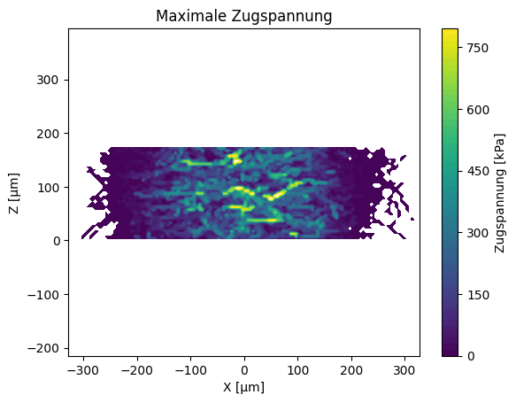

```python
cbar_max_stress = np.nanmax(stress_max)*0.7
levels = np.linspace(0, cbar_max_stress, 55)
fig, ax = plt.subplots()
plt.title('Maximale Zugspannung')
plt.axis('equal')
plt.xlabel('X [µm]')
plt.ylabel('Z [µm]')
contour = ax.contourf(x, z, stress_max, levels=levels, cmap='viridis')
cbar = fig.colorbar(contour, ticks=MaxNLocator(nbins=6))
cbar.set_label('Zugspannung [kPa]')
```

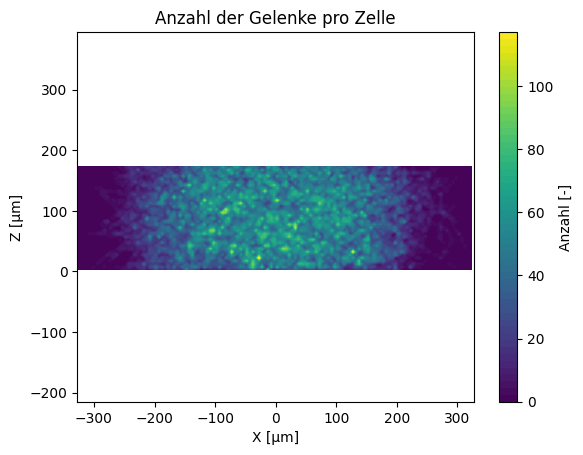

```python
cbar_max_stress = np.nanmax(stress_count)
levels = np.linspace(0, cbar_max_stress, 55)
fig, ax = plt.subplots()
plt.title('Anzahl der Gelenke pro Zelle')
plt.axis('equal')
plt.xlabel('X [µm]')
plt.ylabel('Z [µm]')
contour = ax.contourf(x, z, stress_count, levels=levels, cmap='viridis')
cbar = fig.colorbar(contour, ticks=MaxNLocator(nbins=6))
cbar.set_label('Anzahl [-]')
```

```python
df.describe()
```

|  | id_from | id_to | pos_x | pos_y | pos_z | stress_tensile_wall | radius | radius_3d | P2 |
| --- | --- | --- | --- | --- | --- | --- | --- | --- | --- |
| count | 129837.000000 | 129837.000000 | 129837.000000 | 129837.000000 | 129837.000000 | 129837.000000 | 129837.000000 | 129837.000000 | 129837.000000 |
| mean | 60390.843265 | 63114.699100 | -1.951587 | 13.737188 | 89.815286 | 21.167441 | 147.091729 | 155.741460 | -0.119788 |
| std | 35588.602840 | 36091.185781 | 118.888847 | 103.857563 | 48.565134 | 68.065773 | 59.421776 | 54.990312 | 0.404889 |
| min | 1.000000 | 2.000000 | -310.038000 | -276.395000 | 3.144430 | 0.000000 | 0.504789 | 7.541114 | -0.500000 |
| 25% | 29490.000000 | 31923.000000 | -95.825300 | -67.860600 | 48.552600 | 0.000000 | 104.257019 | 114.764272 | -0.451666 |
| 50% | 59759.000000 | 63382.000000 | -1.619870 | 9.589480 | 89.692600 | 0.091750 | 149.729606 | 156.957527 | -0.279865 |
| 75% | 90840.000000 | 94492.000000 | 91.813900 | 92.865500 | 130.369000 | 3.614287 | 191.151419 | 196.163496 | 0.111139 |
| max | 124598.000000 | 124599.000000 | 315.437000 | 328.369000 | 177.016000 | 1136.281489 | 340.257117 | 333.717443 | 0.999917 |

# Spannungen innerhalb einzelner Kugelschalen

Untersuchung der mittleren und maximalen Spannungen abhängig von der Kugelschale mit dem Schwerpunkt des Pellets als Mittelpunkt

Erstellen von Intervallen für die Kugelschalen und Berechnung der mittleren und maximalen Spannung, sowie der Anzahl der Gelenke pro Schale

```python
import math

bins_min = 0
bins_step = 5

# find max of radius_3d and round to next whole bins_step
bins_max = math.ceil(df['radius_3d'].max() / bins_step) * bins_step
bins = np.arange(bins_min, bins_max, bins_step)

# Create a new column 'radius_3d_bin' with bin labels
df['radius_3d_bin'] = pd.cut(df['radius_3d'], bins=bins, right=False)

# Calculate max stress_tensile for each radius_3d bin
max_stress_by_bin = df.groupby('radius_3d_bin', observed=True)['stress_tensile_wall'].max().reset_index()
max_stress_by_bin.rename(columns={'stress_tensile_wall' : 'stress_tensile_max'}, inplace=True)

# Calculate mean stress_tensile for each radius_3d bin
mean_stress_by_bin = df.groupby('radius_3d_bin', observed=True)['stress_tensile_wall'].mean().reset_index()
mean_stress_by_bin.rename(columns={'stress_tensile_wall' : 'stress_tensile_mean'}, inplace=True)


# count the values (joints) per bin
count_by_bin = df['radius_3d_bin'].value_counts().reset_index()
count_by_bin['midpoint'] = count_by_bin['radius_3d_bin'].apply(lambda interval: (interval.left + interval.right) / 2)
# count_by_bin.columns = ['radius_3d_bin', 'count']
count_by_bin = count_by_bin.sort_values(by='radius_3d_bin').reset_index(drop=True)

df_by_bin_sphere = pd.merge(count_by_bin, max_stress_by_bin, on='radius_3d_bin', how='outer')
df_by_bin_sphere = pd.merge(df_by_bin_sphere, mean_stress_by_bin, on='radius_3d_bin', how='outer')
df_by_bin_sphere
```

|  | radius_3d_bin | count | midpoint | stress_tensile_max | stress_tensile_mean |
| --- | --- | --- | --- | --- | --- |
| 0 | [0, 5) | 0 | 2.5 | NaN | NaN |
| 1 | [5, 10) | 28 | 7.5 | 1029.193708 | 461.443111 |
| 2 | [10, 15) | 58 | 12.5 | 1102.191300 | 189.614776 |
| 3 | [15, 20) | 92 | 17.5 | 1098.057458 | 96.682195 |
| 4 | [20, 25) | 199 | 22.5 | 675.984716 | 63.840862 |
| ... | ... | ... | ... | ... | ... |
| 61 | [305, 310) | 58 | 307.5 | 0.543258 | 0.179403 |
| 62 | [310, 315) | 33 | 312.5 | 0.429409 | 0.217765 |
| 63 | [315, 320) | 17 | 317.5 | 0.370764 | 0.241238 |
| 64 | [320, 325) | 10 | 322.5 | 0.346727 | 0.171000 |
| 65 | [325, 330) | 7 | 327.5 | 0.198552 | 0.141250 |

66 rows × 5 columns

Plotten der mittleren Spannungen sowie Anzahl der Gelenke je Kugelschale

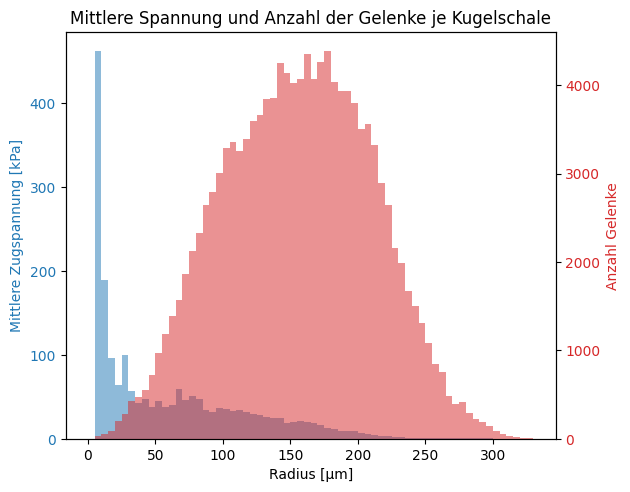

```python
# Specify the width of the bars
bar_width = bins_step

# Plot mean stress_tensile
fig, ax1 = plt.subplots()

color = 'tab:blue'
ax1.set_xlabel('Radius [µm]')
ax1.set_ylabel('Mittlere Zugspannung [kPa]', color=color)
ax1.bar(df_by_bin_sphere['midpoint'], df_by_bin_sphere['stress_tensile_mean'], alpha=0.5, color=color, width=bar_width)
ax1.tick_params(axis='y', labelcolor=color)

# Create a second y-axis for count
ax2 = ax1.twinx()
color = 'tab:red'
ax2.set_ylabel('Anzahl Gelenke', color=color)
ax2.bar(df_by_bin_sphere['midpoint'], df_by_bin_sphere['count'], alpha=0.5, color=color, width=bar_width)
ax2.tick_params(axis='y', labelcolor=color)

fig.tight_layout()
plt.title('Mittlere Spannung und Anzahl der Gelenke je Kugelschale')
plt.show()
```

Plotten der maximalen Spannungen sowie Anzahl der Gelenke je Kugelschale

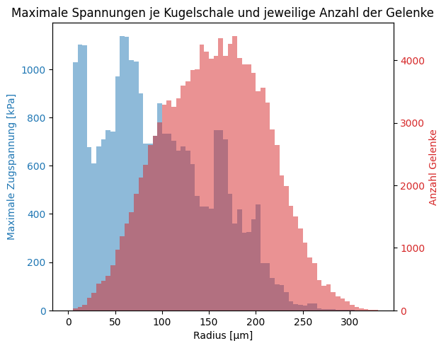

```python
# Specify the width of the bars
bar_width = bins_step

# Plot max stress_tensile
fig, ax1 = plt.subplots()

color = 'tab:blue'
ax1.set_xlabel('Radius [µm]')
ax1.set_ylabel('Maximale Zugspannung [kPa]', color=color)
ax1.bar(df_by_bin_sphere['midpoint'], df_by_bin_sphere['stress_tensile_max'], alpha=0.5, color=color, width=bar_width)
ax1.tick_params(axis='y', labelcolor=color)

# Create a second y-axis for count
ax2 = ax1.twinx()
color = 'tab:red'
ax2.set_ylabel('Anzahl Gelenke', color=color)
ax2.bar(df_by_bin_sphere['midpoint'], df_by_bin_sphere['count'], alpha=0.5, color=color, width=bar_width)
ax2.tick_params(axis='y', labelcolor=color)

fig.tight_layout()
plt.title('Maximale Spannungen je Kugelschale und jeweilige Anzahl der Gelenke')
plt.show()
```

# Erweiterung, da Kugelschalen durch Platten begrenzt sind

Korrektur der vorherigen Auswertung durch Darstellung der Gelenke pro Volumeneinheit (µm³) statt allein der Anzahl.  
Dabei bezogen auf die Kugelschale im Abstand des Radius und unter der Berücksichtigung,  
dass Kugelsegmente außerhalb der Platte (blau) abgeschnitten werden.

[figure not shown]

Zunächst wird das Volumen der Kugelschale zwischen den Radien r und R berechnet:

$ V = \frac{4}{3} \pi (R^3 - r^3) $

Ziel ist es, die Schalensegmente, die durch die obere und untere Platte abgeschnitten werden von dem Volumen abzuziehen, um in etwa folgendes zu erreichen:

[figure not shown]

Die Volumina der zwei Segmente lassen sich [wie folgt](https://rechneronline.de/pi/kugelschalensegment.php) berechnen.

$V_{seg 1,2} = \frac{\pi}{3} \left( h_{1,2}^2 \cdot (3R - h_{1,2}) - i_{1,2}^2 \cdot (3r - i_{1,2}) \right) $

[figure not shown]

Berechnung der tatsächlichen Kugelschalenvolumina zwischen den Platten und der Gelenke pro µm³

```python
z_mean = df['pos_z'].mean() # center sphere is center of mass

def sphere_volume(interval):
    R = interval.right # outer radius
    r = interval.left # inner radius
    volume = 4/3 * math.pi * (R**3 - r**3) # calculate volume of sphere shell
    h1 = z_mean + R - z_plate_max # positive if outer radius higher than plate

    if h1 > 0: # cut shell segment that is higher than top plate
        i1 =  z_mean + r - z_plate_max
        if i1 < 0:
            i1=0
        volume -= math.pi/3 * (h1**2 * (3*R - h1) - i1**2 * (3*r - i1))
        # V = π/3 * [ h² * (3R-h) - i² * (3r-i) ]
    h2 = -(z_mean - R - z_plate_min)
    if h2 > 0: # cut shell segment that is lower than bottom plate
        i2 = -z_mean + r + z_plate_min
        if i2 < 0:
            i2=0
        volume -= math.pi/3 * (h2**2 * (3*R - h2) - i2**2 * (3*r - i2))
    return volume

df_by_bin_sphere['sphere_volume'] = df_by_bin_sphere['radius_3d_bin'].apply(sphere_volume).astype(float)
df_by_bin_sphere['count_per_volume'] = df_by_bin_sphere['count'] / df_by_bin_sphere['sphere_volume']
df_by_bin_sphere
```

|  | radius_3d_bin | count | midpoint | stress_tensile_max | stress_tensile_mean | sphere_volume | count_per_volume |
| --- | --- | --- | --- | --- | --- | --- | --- |
| 0 | [0, 5) | 0 | 2.5 | NaN | NaN | 5.235988e+02 | 0.000000 |
| 1 | [5, 10) | 28 | 7.5 | 1029.193708 | 461.443111 | 3.665191e+03 | 0.007639 |
| 2 | [10, 15) | 58 | 12.5 | 1102.191300 | 189.614776 | 9.948377e+03 | 0.005830 |
| 3 | [15, 20) | 92 | 17.5 | 1098.057458 | 96.682195 | 1.937315e+04 | 0.004749 |
| 4 | [20, 25) | 199 | 22.5 | 675.984716 | 63.840862 | 3.193953e+04 | 0.006231 |
| ... | ... | ... | ... | ... | ... | ... | ... |
| 61 | [305, 310) | 58 | 307.5 | 0.543258 | 0.179403 | 1.740529e+06 | 0.000033 |
| 62 | [310, 315) | 33 | 312.5 | 0.429409 | 0.217765 | 1.768830e+06 | 0.000019 |
| 63 | [315, 320) | 17 | 317.5 | 0.370764 | 0.241238 | 1.797132e+06 | 0.000009 |
| 64 | [320, 325) | 10 | 322.5 | 0.346727 | 0.171000 | 1.825433e+06 | 0.000005 |
| 65 | [325, 330) | 7 | 327.5 | 0.198552 | 0.141250 | 1.853734e+06 | 0.000004 |

66 rows × 7 columns

Plotten der maximalen Spannungen sowie der Anzahl der Gelenke pro µm³ (die [in etwa] proportional zur Feststoffdichte sein sollte)

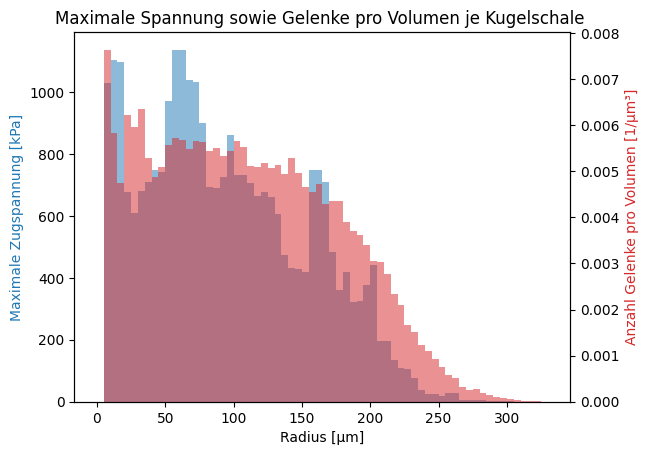

```python
bar_width = bins_step

fig, ax1 = plt.subplots()

color = 'tab:blue'
ax1.set_xlabel('Radius [µm]')
ax1.set_ylabel('Maximale Zugspannung [kPa]', color=color)
ax1.bar(df_by_bin_sphere['midpoint'], df_by_bin_sphere['stress_tensile_max'], alpha=0.5, color=color, width=bar_width)

ax2 = ax1.twinx()
color = 'tab:red'
ax2.set_ylabel('Anzahl Gelenke pro Volumen [1/µm³]', color=color)
ax2.bar(df_by_bin_sphere['midpoint'], df_by_bin_sphere['count_per_volume'], alpha=0.5, color=color, width=bar_width)

plt.title('Maximale Spannung sowie Gelenke pro Volumen je Kugelschale ')
plt.show()
```

# Auswertung über Hohlzylinder mit den Radien r und R statt Kugelschalen

(Zylinder senkrecht zu den einzelnen Platten. Schwerpunkt des Pellts befindet sich in der Mitte (X-Y) des Zylinders)

Auswertung analog zur Auswertung der Kugelschalen

```python
bins_min = 0
bins_step = 5

# find max of radius_3d and round to next whole bins_step
bins_max = math.ceil(df['radius'].max() / bins_step) * bins_step
bins = np.arange(bins_min, bins_max, bins_step)

# Create a new column 'radius_3d_bin' with bin labels
df['radius_bin'] = pd.cut(df['radius'], bins=bins, right=False)

# Calculate max stress_tensile for each radius bin
max_stress_by_bin = df.groupby('radius_bin', observed=True)['stress_tensile_wall'].max().reset_index()
max_stress_by_bin.rename(columns={'stress_tensile_wall' : 'stress_tensile_max'}, inplace=True)

# Calculate mean stress_tensile for each radius bin
mean_stress_by_bin = df.groupby('radius_bin', observed=True)['stress_tensile_wall'].mean().reset_index()
mean_stress_by_bin.rename(columns={'stress_tensile_wall' : 'stress_tensile_mean'}, inplace=True)

# count the values (joints) per bin
count_by_bin = df['radius_bin'].value_counts().reset_index()
count_by_bin['midpoint'] = count_by_bin['radius_bin'].apply(lambda interval: (interval.left + interval.right) / 2)
# count_by_bin.columns = ['radius_bin', 'count']
count_by_bin = count_by_bin.sort_values(by='radius_bin').reset_index(drop=True)

df_by_bin_cylinder = pd.merge(count_by_bin, max_stress_by_bin, on='radius_bin', how='outer')
df_by_bin_cylinder = pd.merge(df_by_bin_cylinder, mean_stress_by_bin, on='radius_bin', how='outer')
df_by_bin_cylinder
```

|  | radius_bin | count | midpoint | stress_tensile_max | stress_tensile_mean |
| --- | --- | --- | --- | --- | --- |
| 0 | [0, 5) | 79 | 2.5 | 541.286779 | 55.284332 |
| 1 | [5, 10) | 314 | 7.5 | 1102.191300 | 52.620461 |
| 2 | [10, 15) | 428 | 12.5 | 1044.413543 | 69.338027 |
| 3 | [15, 20) | 546 | 17.5 | 882.505550 | 67.520150 |
| 4 | [20, 25) | 693 | 22.5 | 1030.021117 | 49.112687 |
| ... | ... | ... | ... | ... | ... |
| 63 | [315, 320) | 17 | 317.5 | 0.370764 | 0.227545 |
| 64 | [320, 325) | 6 | 322.5 | 0.233923 | 0.206721 |
| 65 | [325, 330) | 7 | 327.5 | 0.219751 | 0.204843 |
| 66 | [330, 335) | 5 | 332.5 | 0.212588 | 0.185727 |
| 67 | [335, 340) | 3 | 337.5 | 0.136930 | 0.121363 |

68 rows × 5 columns

Berechnung der Hohlzylindervolumina zwischen den Platten (Angenommen z<sub>1</sub> = 0 µm, z<sub>2</sub> = 180 µm)  
sowie der Gelenke pro µm³

```python
z_mean = df['pos_z'].mean() # center sphere is center of mass

h_cylinder = z_plate_max -  z_plate_min

def cylinder_volume(interval):
    R = interval.right # outer radius
    r = interval.left # inner radius
    volume = math.pi * (R**2 - r**2) * h_cylinder # calculate volume of hollow cylinder
    return volume

df_by_bin_cylinder['cylinder_volume'] = df_by_bin_cylinder['radius_bin'].apply(cylinder_volume).astype(float)
df_by_bin_cylinder['count_per_volume'] = df_by_bin_cylinder['count'] / df_by_bin_cylinder['cylinder_volume']
df_by_bin_cylinder
```

|  | radius_bin | count | midpoint | stress_tensile_max | stress_tensile_mean | cylinder_volume | count_per_volume |
| --- | --- | --- | --- | --- | --- | --- | --- |
| 0 | [0, 5) | 79 | 2.5 | 541.286779 | 55.284332 | 1.415064e+04 | 0.005583 |
| 1 | [5, 10) | 314 | 7.5 | 1102.191300 | 52.620461 | 4.245193e+04 | 0.007397 |
| 2 | [10, 15) | 428 | 12.5 | 1044.413543 | 69.338027 | 7.075321e+04 | 0.006049 |
| 3 | [15, 20) | 546 | 17.5 | 882.505550 | 67.520150 | 9.905449e+04 | 0.005512 |
| 4 | [20, 25) | 693 | 22.5 | 1030.021117 | 49.112687 | 1.273558e+05 | 0.005441 |
| ... | ... | ... | ... | ... | ... | ... | ... |
| 63 | [315, 320) | 17 | 317.5 | 0.370764 | 0.227545 | 1.797132e+06 | 0.000009 |
| 64 | [320, 325) | 6 | 322.5 | 0.233923 | 0.206721 | 1.825433e+06 | 0.000003 |
| 65 | [325, 330) | 7 | 327.5 | 0.219751 | 0.204843 | 1.853734e+06 | 0.000004 |
| 66 | [330, 335) | 5 | 332.5 | 0.212588 | 0.185727 | 1.882035e+06 | 0.000003 |
| 67 | [335, 340) | 3 | 337.5 | 0.136930 | 0.121363 | 1.910337e+06 | 0.000002 |

68 rows × 7 columns

Plotten der maximalen Spannungen sowie der Anzahl der Gelenke pro µm³ (-> ~ Feststoffdichte)

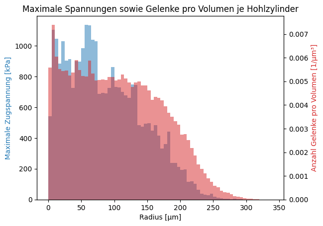

```python
bar_width = bins_step

fig, ax1 = plt.subplots()

color = 'tab:blue'
ax1.set_xlabel('Radius [µm]')
ax1.set_ylabel('Maximale Zugspannung [kPa]', color=color)
ax1.bar(df_by_bin_cylinder['midpoint'], df_by_bin_cylinder['stress_tensile_max'], alpha=0.5, color=color, width=bar_width)

ax2 = ax1.twinx()
color = 'tab:red'
ax2.set_ylabel('Anzahl Gelenke pro Volumen [1/µm³]', color=color)
ax2.bar(df_by_bin_cylinder['midpoint'], df_by_bin_cylinder['count_per_volume'], alpha=0.5, color=color, width=bar_width)

plt.title('Maximale Spannungen sowie Gelenke pro Volumen je Hohlzylinder')
plt.show()
```

# To Do

- Berechnung der Feststoffdichte (statt Anzahl pro µm³) über Ansatz von Charlotte
- Abhängigkeit der Zugspannung von der Ausrichtung der Elemente

```python
V_joint = math.pi * (d_hypha/2)**2 * h_hypha # V_cylinder = pi * (d/2)² * h

df_by_bin_cylinder['density_solid'] = df_by_bin_cylinder['count'] * V_joint / df_by_bin_cylinder['cylinder_volume']
df_by_bin_sphere['density_solid'] = df_by_bin_sphere['count'] * V_joint / df_by_bin_sphere['sphere_volume']
df_by_bin_cylinder
```

|  | radius_bin | count | midpoint | stress_tensile_max | stress_tensile_mean | cylinder_volume | count_per_volume | density_solid |
| --- | --- | --- | --- | --- | --- | --- | --- | --- |
| 0 | [0, 5) | 79 | 2.5 | 541.286779 | 55.284332 | 1.415064e+04 | 0.005583 | 0.274096 |
| 1 | [5, 10) | 314 | 7.5 | 1102.191300 | 52.620461 | 4.245193e+04 | 0.007397 | 0.363148 |
| 2 | [10, 15) | 428 | 12.5 | 1044.413543 | 69.338027 | 7.075321e+04 | 0.006049 | 0.296995 |
| 3 | [15, 20) | 546 | 17.5 | 882.505550 | 67.520150 | 9.905449e+04 | 0.005512 | 0.270626 |
| 4 | [20, 25) | 693 | 22.5 | 1030.021117 | 49.112687 | 1.273558e+05 | 0.005441 | 0.267157 |
| ... | ... | ... | ... | ... | ... | ... | ... | ... |
| 63 | [315, 320) | 17 | 317.5 | 0.370764 | 0.227545 | 1.797132e+06 | 0.000009 | 0.000464 |
| 64 | [320, 325) | 6 | 322.5 | 0.233923 | 0.206721 | 1.825433e+06 | 0.000003 | 0.000161 |
| 65 | [325, 330) | 7 | 327.5 | 0.219751 | 0.204843 | 1.853734e+06 | 0.000004 | 0.000185 |
| 66 | [330, 335) | 5 | 332.5 | 0.212588 | 0.185727 | 1.882035e+06 | 0.000003 | 0.000130 |
| 67 | [335, 340) | 3 | 337.5 | 0.136930 | 0.121363 | 1.910337e+06 | 0.000002 | 0.000077 |

68 rows × 8 columns

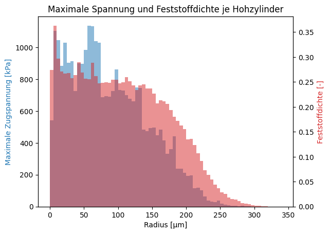

```python
bar_width = bins_step

fig, ax1 = plt.subplots()

color = 'tab:blue'
ax1.set_xlabel('Radius [µm]')
ax1.set_ylabel('Maximale Zugspannung [kPa]', color=color)
ax1.bar(df_by_bin_cylinder['midpoint'], df_by_bin_cylinder['stress_tensile_max'], alpha=0.5, color=color, width=bar_width)

ax2 = ax1.twinx()
color = 'tab:red'
ax2.set_ylabel('Feststoffdichte [-]', color=color)
ax2.bar(df_by_bin_cylinder['midpoint'], df_by_bin_cylinder['density_solid'], alpha=0.5, color=color, width=bar_width)

plt.title('Maximale Spannung und Feststoffdichte je Hohzylinder')
plt.show()
```

Ein (vermutlich minimaler) Fehlereinfluss bei der Feststoffdichte ist die Verwendung der Gelenke statt Elementmittelpunkte. Lösung:

- Berechnung der Mittelpunkte über id_from und id_to oder
- Export der Elementdaten aus Rocky für echten Schwerpunkt